# Week 4

```r
setwd("~/Nat Resource Stats R")
getwd
```

```r
library(RCurl)
library(RCurl)
guns=read.csv(text=getURL("https://raw.githubusercontent.com/OscarFHC/NRE538_GSRA/master/Labs/NRE538_Lab2/guns.csv"), sep=",", header=T, comment.char="#")
```

One Sample t-test

```r
guns.MI = subset(guns, state=="Michigan")
t.test(guns.MI[,"murder"], mu=9)
```

```
##
##  One Sample t-test
##
## data:  guns.MI[, "murder"]
## t = 2.3794, df = 22, p-value = 0.02644
## alternative hypothesis: true mean is not equal to 9
## 95 percent confidence interval:
##   9.085973 10.253157
## sample estimates:
## mean of x
##  9.669565
```

Exercise 1 Null Hypotheses One Tail: The mean robery rate in Michigan state over the years is not greater than 100.

```r
t.test(guns.MI[,"robbery"], mu=100, alternative = 'greater')
```

```
##
##  One Sample t-test
##
## data:  guns.MI[, "robbery"]
## t = 13.768, df = 22, p-value = 1.361e-12
## alternative hypothesis: true mean is greater than 100
## 95 percent confidence interval:
##  217.2223      Inf
## sample estimates:
## mean of x
##  233.9261
```

Data from t.test: data: guns.MI[, “robbery”] t = 13.768, df = 22, p-value = 1.361e-12 alternative hypothesis: true mean is greater than 100 95 percent confidence interval: 217.2223 Inf sample estimates: mean of x 233.9261

From this data, we recieved a p-value of 1.361e-12, which is well under the p-value of 0.05. With the p-value we recieved, we can safely reject the null hypothesis. This is because the p-value is below 0.05, and we can infact infer that the robbery rate in Michigan state is greater than 100.

Null Hypotheses Two Tail: The mean robery rate over the years is equal to 100.

```r
t.test(guns.MI[,"robbery"], mu=100, alternative='two.sided')
```

```
##
##  One Sample t-test
##
## data:  guns.MI[, "robbery"]
## t = 13.768, df = 22, p-value = 2.721e-12
## alternative hypothesis: true mean is not equal to 100
## 95 percent confidence interval:
##  213.7522 254.1000
## sample estimates:
## mean of x
##  233.9261
```

data: guns.MI[, “robbery”] t = 13.768, df = 22, p-value = 2.721e-12 alternative hypothesis: true mean is not equal to 100 95 percent confidence interval: 213.7522 254.1000 sample estimates: mean of x 233.9261

After running the two-tailed t.test, we have recieved a p-value of 2.721e-12, which is less than 0.05. This means that we can reject our null hypothesis, our mean will not be equal to 100. We can safely then conclude that the mean robbery rate in the state of Michigan is not equal to 100.

1.2 Two Sample t-test:

```r
guns.WAS = subset(guns, state=="Washington")
guns.MIN = subset(guns, state=="Minnesota")
t.test(guns.WAS[,"murder"], guns.MIN[,"murder"], paired=FALSE)
```

```
##
##  Welch Two Sample t-test
##
## data:  guns.WAS[, "murder"] and guns.MIN[, "murder"]
## t = 12.104, df = 43.616, p-value = 1.546e-15
## alternative hypothesis: true difference in means is not equal to 0
## 95 percent confidence interval:
##  1.753891 2.454804
## sample estimates:
## mean of x mean of y
##  4.773913  2.669565
```

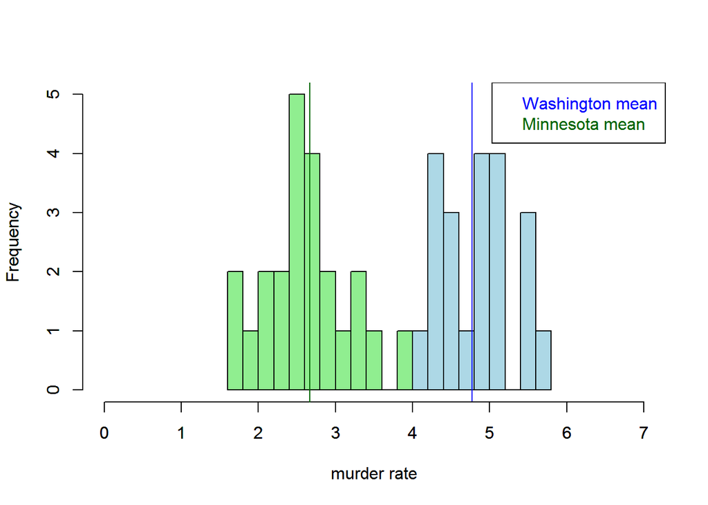

```r
hist(guns.WAS[,"murder"], breaks=15, col="light blue", xlim=c(0, 7), ylim=c(0,5), xlab="murder rate", main="")
abline(v=mean(guns.WAS[,"murder"]), col="blue")
par(new=TRUE)
hist(guns.MIN[,"murder"], breaks=15, col="light green", xlim=c(0, 7), ylim=c(0,5), xlab="", main="")
abline(v=mean(guns.MIN[,"murder"]), col="dark green")
  legend("topright", legend = c("Washington mean", "Minnesota mean"),text.col=c("blue", "dark green"))
```

```r
shapiro.test(guns.WAS[,"murder"])
```

```
##
##  Shapiro-Wilk normality test
##
## data:  guns.WAS[, "murder"]
## W = 0.94148, p-value = 0.1933
```

```r
shapiro.test(guns.MIN[,"murder"])
```

```
##
##  Shapiro-Wilk normality test
##
## data:  guns.MIN[, "murder"]
## W = 0.98013, p-value = 0.9083
```

```r
var.test(guns.WAS[,"murder"], guns.MIN[,"murder"])
```

```
##
##  F test to compare two variances
##
## data:  guns.WAS[, "murder"] and guns.MIN[, "murder"]
## F = 1.2072, num df = 22, denom df = 22, p-value = 0.6626
## alternative hypothesis: true ratio of variances is not equal to 1
## 95 percent confidence interval:
##  0.5119867 2.8464432
## sample estimates:
## ratio of variances
##           1.207204
```

1.3.1 One Sample Comparison

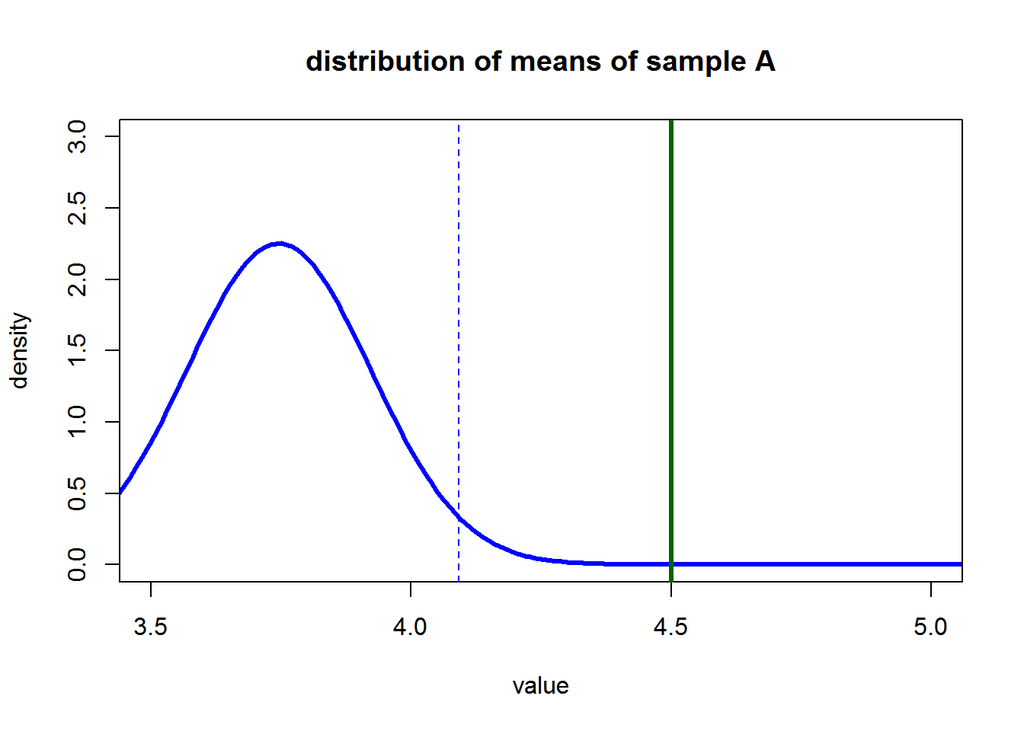

```r
muA=4
sdA=1
A=rnorm(30, mean=muA, sd=sdA)
A.mean=mean(A)

A.mean.SE=sqrt(var(A)/length(A))
A.mean.CI=c(A.mean-qnorm(0.975)*A.mean.SE, A.mean+qnorm(0.975)*A.mean.SE)

xs = seq(0, 15, by =0.01)
fA = dnorm(xs, mean=A.mean, sd=A.mean.SE)
plot(fA~xs, type="l", lwd=3, col="blue", xlim=c(3.5, 5), ylim=c(0, 3),
     main="distribution of means of sample A", xlab="value", ylab="density")
abline(v=c(qnorm(0.025, mean=A.mean, sd=A.mean.SE), qnorm(0.975, mean=A.mean, sd=A.mean.SE)), col="blue", lty="dashed")
abline(v=4.5, col="dark green", lty="solid", lwd=3)
```

```r
p.m.=2*(1-pnorm(4.5, mean=A.mean, sd=A.mean.SE))
p.m.
```

```
## [1] 2.035498e-05
```

```r
t.test(A, mu=4.5)$p.value
```

```
## [1] 0.0001961582
```

Exercise 2:

```r
t.test(guns.MIN[,"murder"],guns.WAS[,"murder"], paired=FALSE, var.equal = TRUE)
```

```
##
##  Two Sample t-test
##
## data:  guns.MIN[, "murder"] and guns.WAS[, "murder"]
## t = -12.104, df = 44, p-value = 1.347e-15
## alternative hypothesis: true difference in means is not equal to 0
## 95 percent confidence interval:
##  -2.454717 -1.753979
## sample estimates:
## mean of x mean of y
##  2.669565  4.773913
```

Two Sample t-test

data: guns.MIN[, “murder”] and guns.WAS[, “murder”] t = -12.104, df = 44, p-value = 1.347e-15 alternative hypothesis: true difference in means is not equal to 0 95 percent confidence interval: -2.454717 -1.753979 sample estimates: mean of x mean of y 2.669565 4.773913

From this test we see that the p-value is 1.347e-15. This means that we can reject the null hypotheses in that the murder rates of Washington and Minnesota are the same. This is because the p-value is less than 0.05, and so we reject the null hypotheses. We can therefore conclude that the murder rates in Washington state and the murder rates in Minnesota state are significantly different from each other.